ESM 505/ESR 605 : Data Management, Spring 2014

# Module 13: Mapping in R

There are a lot of ways to create maps in R. In fact, there are many different packages to choose from when it comes to making maps. In this module, I will cover some of the basics with a few packages to give you an overview of the options.

There are also lots of tutorials online if you want more information.

- http://statacumen.com/teach/SC1/SC1_16_Maps.pdf
- https://github.com/hadley/ggplot2/wiki/plotting-polygon-shapefiles
- http://cran.r-project.org/web/views/Spatial.html
- http://www.molecularecologist.com/2012/09/making-maps-with-r/
- http://cameron.bracken.bz/finally-an-easy-way-to-fix-the-horizontal-lines-in-ggplot2-maps
- http://rpubs.com/alobo/getmapCRS

## Large scale maps with polical boudaries (world, countries, counties)

Sometimes you want a very simple clean map with just a few polical boundries. This is particularly useful for maps on a large scale (the world, the state, the county) to show where your study site is, but it's not so good if you want to show your particular sampling locations around a small pond.

### Simple maps using “maps” package

The simplist way to make a map is using the map() function in the “maps” package. This package comes with map data for the countries of the world, US states, US counties, and a select few other country maps.

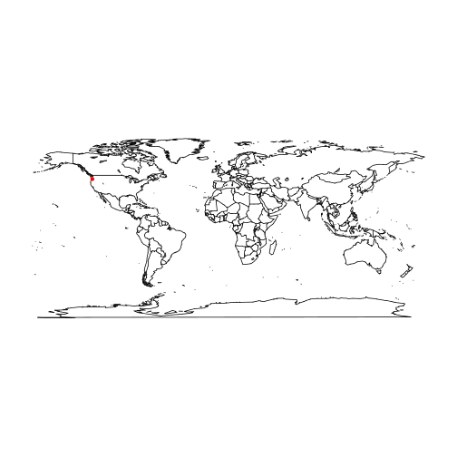

```r
library(maps)
# simple map of the world
map("world")

# add a point (roughly portland)
pdx_lat <- 45.52
pdx_lon <- -122.68
points(pdx_lon, pdx_lat, col = "red", pch = 20, cex = 1)
```

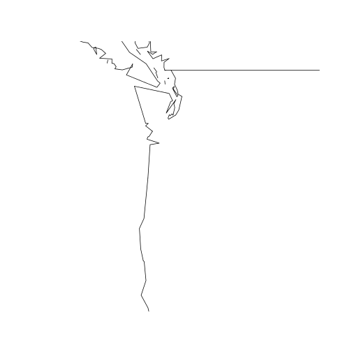

```r
# If you want, you can zoom into the map by altering the xlim and ylim.
# Let's zooom in to the Pacific Northwest.
map("world", xlim = c(-130, -115), ylim = c(40, 50))
```

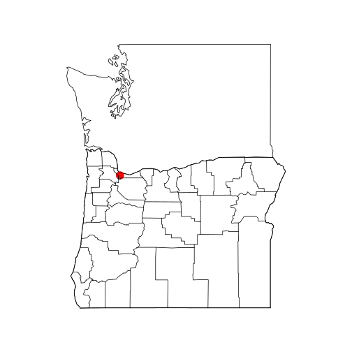

```r
# Yick, the resolution isn't so hot.  Let's try using the state level maps.
map("state", region = c("Washington", "Oregon"))

# Add a point for Portland.
points(pdx_lon, pdx_lat, col = "red", pch = 20, cex = 3)

# Now let's add the counties to Oregon
map("county", "Oregon", add = T)
```

## Plotting Shapefiles

If you want to move beyond the limits of the maps packacke you'll want to be able to plot shapefiles. If you are familiar with GIS you probably know what those are. If not, just think of them as vectorized map files.

### Plotting a shapefile using “maptools” package

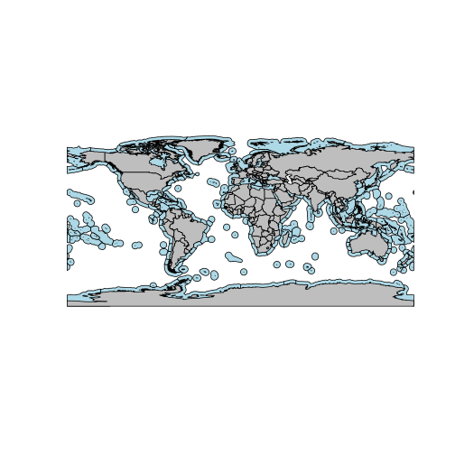

```r
library(maptools)
## use readShapePoly to read a polygon shapefile.  Use readShapeLine for a
## line shapefile and readShapePoint for a points shapefile

# Countries of the world shapefile
countries <- readShapePoly("~/Geoprocessing_Shapefiles/Countries.shp")
# Marine Ecoregions of the World
MEOW <- readShapePoly("~/Geoprocessing_Shapefiles/meow_ecos.shp")

plot(MEOW, col = "light blue")
plot(countries, col = "gray", add = T)
```

### Plotting a shapefile using the “rgdal” package

```r
library(rgdal)
dsn <- path.expand("~/Geoprocessing_Shapefiles")
countries2 <- readOGR(dsn, "Countries")
```

```
## with 250 features and 8 fields
## Feature type: wkbPolygon with 2 dimensions
```

```r
MEOW2 <- readOGR(dsn, "meow_ecos")
```

```
## with 232 features and 9 fields
## Feature type: wkbPolygon with 2 dimensions
```

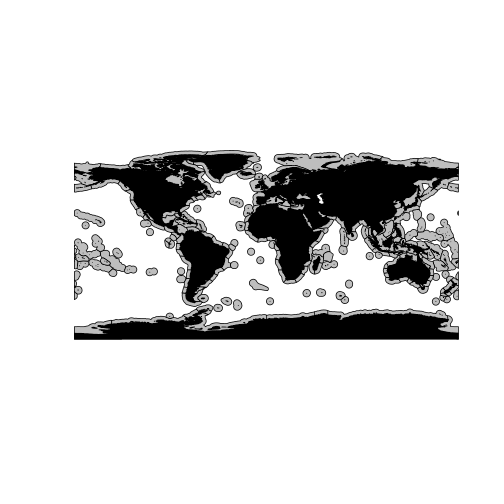

```r
plot(MEOW2, col = "gray")

## fill in the polygons black so you don't see the country borders
plot(countries2, col = "black", add = T)
```

Of course you could use specialized shapefiles at a much smaller scale if you wanted.

## Google Maps for terrain and satellite image based maps

Using Google Maps is a popular way to create a map using satellite imagery. One of the first packages with this option was the “RgoogleMaps” package. While it works just fine, I find it a bit clumsy to work with. I currently prefer the mapping option in the “dismo” package.

The dismo package by the way is also the package to use for *di*stribution *mo*delling (hence the name “dis mo”).

```r
library(dismo)
```

[figure not shown]

```r
# Map of Oregon
OR_map <- gmap("Oregon", size = c(600, 600))
plot(OR_map)
```

[figure not shown]

```r
# Road map of Portland
PDX_map <- gmap("Portland, OR", type = "roadmap")
plot(PDX_map)
```

[figure not shown]

```r
# That looks a bit blurry.  But we can interpolate..
plot(PDX_map, interpolate = TRUE)
```

[figure not shown]

```r
# Satellite map of Henry Hagg Lake
lake_map <- gmap("Henry Hagg Lake, Oregon", type = "satellite")
plot(lake_map, interpolate = TRUE)
```

```r
# Use the geocode() function to access the Google geocoding API to get point
# for PSU
PSU <- geocode(c("Portland State University"))

# The Map is a raster in Mercator projection so you need to transform the
# lat, lon data you want to plot over it.
PSU_coords <- Mercator(cbind(PSU$longitude, PSU$latitude))

plot(PDX_map, interpolate = TRUE)
```

[figure not shown]

```r
points(PSU_coords, col = "red", pch = 20)
```

```r
# The dismo package comes with a function that lets you pull down species
# data from the GBIF network of occurrence records

# Let's get some beaver data
beaver <- gbif("Castor", "canadensis", geo = TRUE)
```

```
## Castor canadensis : 1262 occurrences found
## 1-1000-1262
```

```r
# drop NA lat/lon data
beaver <- subset(beaver, !is.na(lat) & !is.na(lon))

# Transform the lat/lon to Mercator
beaver_coords <- Mercator(cbind(beaver$lon, beaver$lat))

# Calculate the extent of the beaver data
beaver_extent <- extent(c(min(beaver$lon), max(beaver$lon), min(beaver$lat),
    max(beaver$lat)))

# Get a Google Map for that extent, plot it and then plot the beaver points
beaver_map <- gmap(beaver_extent, type = "satellite")
plot(beaver_map)
```

[figure not shown]

```r
points(beaver_coords, col = "red", pch = 20)
```

```r
# Let's limit that beaver data to Oregon
or_beaver <- subset(beaver, adm1 == "Oregon")

# Transform the lat/lon to Mercator
or_beaver_coords <- Mercator(cbind(or_beaver$lon, or_beaver$lat))

# Plot the beaver occurrences onto a map of Oregon
plot(OR_map, interpolate = TRUE)
```

[figure not shown]

```r
points(or_beaver_coords, col = "red", pch = 20)
```

## ggplot2 style plotting of maps

### Plotting a map in “ggplot2”“ package

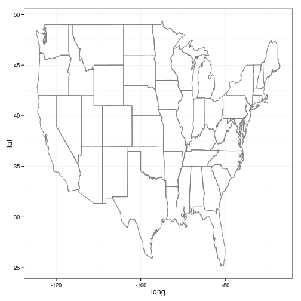

```r
library(ggplot2)

usamap <- ggplot() + borders("state") + theme_bw()

# Use cartesian coordinates
usamap
```

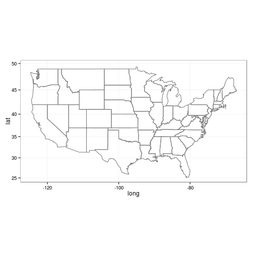

```r
# With mercator projection
usamap + coord_map()
```

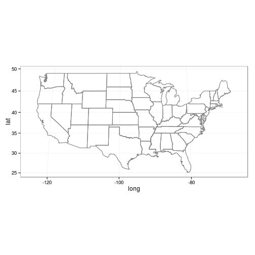

```r
# See ?mapproject for coordinate systems and their parameters
usamap + coord_map("gilbert")
```

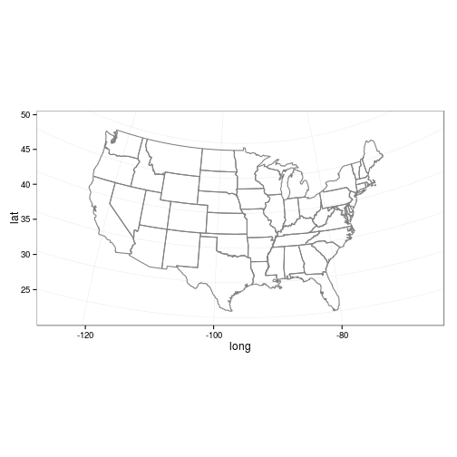

```r
usamap + coord_map("tetra")
```

### Plotting a shapefile in "ggplot2” package

```r
library(ggplot2)
library(gpclib)
library(rgdal)
library(sp)
gpclibPermit()
```

```
## [1] TRUE
```

```r
dsn <- path.expand("~/Geoprocessing_Shapefiles")
world <- readOGR(dsn, "Countries")
```

```
## with 250 features and 8 fields
## Feature type: wkbPolygon with 2 dimensions
```

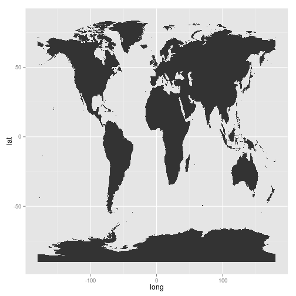

```r
world.fortify <- fortify(world, region = "CNTRY_NAME")
world.map <- ggplot(world.fortify, aes(long, lat, group = group)) + geom_polygon()
world.map
```

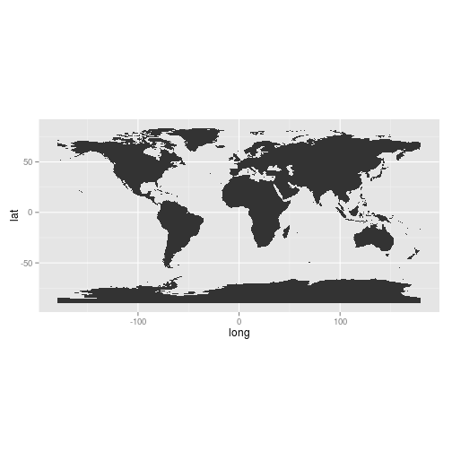

```r
# a little odd
world.map + coord_equal()
```

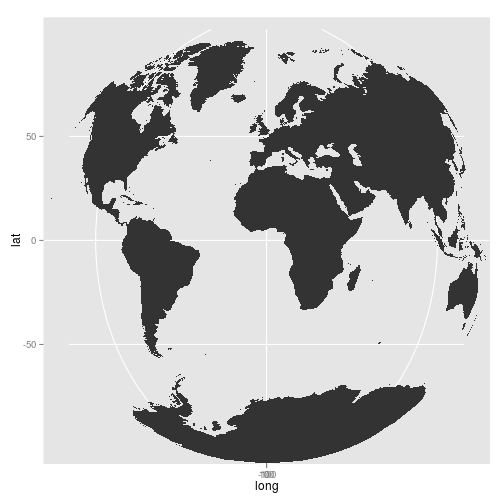

```r
world.map + coord_map("gilbert")
```

## Issues with clipping when you zoom in on polygons in ggplot2

```r
library(PBSmapping)
```

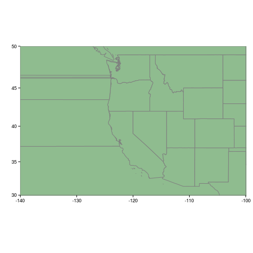

```r
library(ggplot2)
library(maps)


# plot limits
xlim <- c(-140, -100)
ylim <- c(30, 50)

worldmap <- map_data("world")
names(worldmap) <- c("X", "Y", "PID", "POS", "region", "subregion")
worldmap2 <- clipPolys(worldmap, xlim = xlim, ylim = ylim, keepExtra = TRUE)

statemap <- map_data("state")
names(statemap) <- c("X", "Y", "PID", "POS", "region", "subregion")
statemap2 <- clipPolys(statemap, xlim = xlim, ylim = ylim, keepExtra = TRUE)

p <- ggplot() + coord_map(xlim = xlim, ylim = ylim) + geom_polygon(data = worldmap,
    aes(X, Y, group = PID), fill = "darkseagreen", color = "grey50") + geom_polygon(data = statemap,
    aes(X, Y, group = PID), fill = "darkseagreen", color = "grey50") + labs(y = "",
    x = "") + theme_bw()
print(p)
```

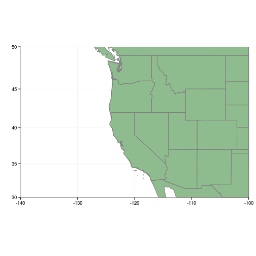

```r
p2 <- ggplot() + coord_map(xlim = xlim, ylim = ylim) + geom_polygon(data = worldmap2,
    aes(X, Y, group = PID), fill = "darkseagreen", color = "grey50") + geom_polygon(data = statemap2,
    aes(X, Y, group = PID), fill = "darkseagreen", color = "grey50") + labs(y = "",
    x = "") + theme_bw()
print(p2)
```

### Plotting onto a Google Map in “ggmaps” package

```r
library(ggmap)
hhl <- get_map("Henry Hagg Lake", zoom = 14)
```

```
## Google Maps API Terms of Service : http://developers.google.com/maps/terms
## Google Maps API Terms of Service : http://developers.google.com/maps/terms
```

[figure not shown]

```r
ggmap(hhl)
```

## Advanced topics (GIS in R)

### Point in Polygon analysis

```r
# load sp package for 'over()' function
library(sp)
# turn beaver data.frame into a spatial data frame by setting coordinates
coordinates(beaver) <- c("lon", "lat")

# reload the countries shapefile from before
dsn <- path.expand("~/Geoprocessing_Shapefiles")
world <- readOGR(dsn, "Countries")
```

```
## with 250 features and 8 fields
## Feature type: wkbPolygon with 2 dimensions
```

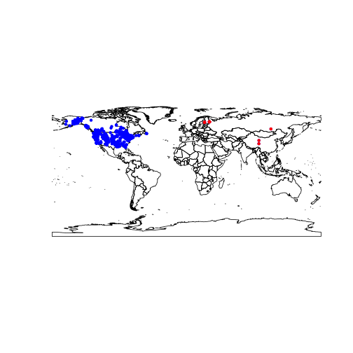

```r
# set the projection of the beaver spatial data to the same as the countries
# shapefile
proj4string(beaver) <- proj4string(world)

# overlay beaver and world and return the 'CNTRY_NAME' for each beaver
# occurrence
overlay <- over(beaver, world)

# add this new CNTRY_NAME field to the beaver spatial data frame
beaver$CNTRY_NAME <- overlay$CNTRY_NAME


# Let's look to see where these beaver lat/lons are outside of the US and
# Canada
Non_NorthAmerican_Beavers <- subset(beaver, CNTRY_NAME != "USA" & CNTRY_NAME !=
    "Canada")

# Let's plot that
plot(world)
points(beaver, pch = 20, col = "blue")
points(Non_NorthAmerican_Beavers, pch = 20, col = "red")
```

## Homework

Make two maps (for your data if possible). The first map should be large regional map using a shapefile or other vector style outline showing your study location. For the second, zoom in a bit to your study location and use a raster based map (like Google Maps) to give a bit more context to the local geography. Place both maps in an R Markdown (.Rmd) document and upload it to the dropbox.